# ASER reading and math corr, does 3 predict 5

This notebook performs additional last minute analysis for the RISE data paper. The notebook:

- Calculates the correlation between grade 3 ASER reading and math scores
- Replicates the graph from the private schools paper showing ASER state averages over time
- Regresses grade 5 scores on grade 3 scores for 2 years earlier and grade 3 scores for same year

## Setup

```r
states <- read_csv("https://raw.githubusercontent.com/dougj892/public-datasets/master/ASER%20trends%20over%20time.csv")
```

## Graph of state values over time

Replicate the graphs from the private schools paper which show grade 3 and grade 5 reading/math scores over time.

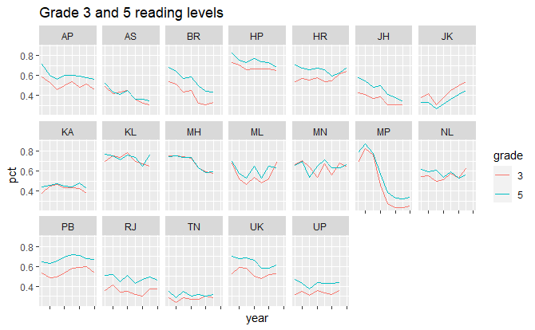

```r
# reshape to long
# drop states which don't have any data for grade 3. This frees up some space in the graph
states_long <- states %>%
  filter(!is.na(std3_read_std1_pvt) & !is.na(std3_subtract_pvt)) %>%
  select(state_abbr, year, starts_with("std")) %>%
  pivot_longer(cols = starts_with("std"), names_to = "series", values_to = "pct") %>%
  mutate(grade = str_extract(series, "\\d"),
         sector = str_extract(series, "(govt)|(pvt)|(all)"),
         subject = str_extract(series, "(read)|(subtract)|(divis)")) %>%
  mutate(subject = if_else(subject != "read", "math", "read"))

#
df_read <- states_long %>% filter((sector == "all") & (subject == "read"))
df_math <- states_long %>% filter((sector == "all") & (subject == "math"))

ggplot(df_read, aes(x = year, y = pct, color = grade)) + geom_line() +
  theme(axis.text.x = element_blank())+
  facet_wrap( ~ state_abbr, nrow = 3) +
  labs(title = "Grade 3 and 5 reading levels")
```

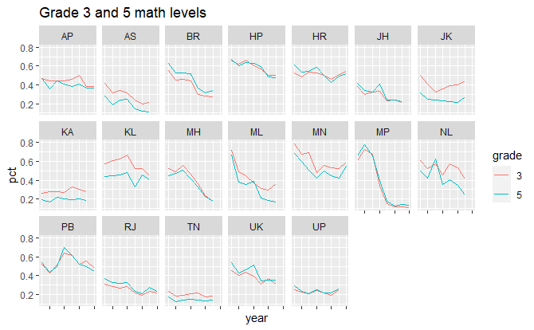

```r
ggplot(df_math, aes(x = year, y = pct, color = grade)) + geom_line() +
  theme(axis.text.x = element_blank())+
  facet_wrap( ~ state_abbr, nrow = 3) +
  labs(title = "Grade 3 and 5 math levels")
```

## Calculate correlation

```r
corrs <- states %>%
  group_by(year) %>%
  summarise(kendall = cor(std3_read_std1_all, std3_subtract_all, use="pairwise.complete.obs", method="kendall"),
            pearson = cor(std3_read_std1_all, std3_subtract_all, use="pairwise.complete.obs", method="pearson"),
            spearman = cor(std3_read_std1_all, std3_subtract_all, use="pairwise.complete.obs", method="spearman"))
corrs %>% summarise_all(mean, na.rm = TRUE)
```

| year | kendall | pearson | spearman |
| --- | --- | --- | --- |
| 2010 | 0.6567437 | 0.8329502 | 0.8269923 |

## Regression

To test whether non-persistent shocks are changes to actual learning or just noise, I perform the following regression:

$$y_t = \alpha+\beta y_{t-1}+\gamma x_t +\delta[x_{t-2}-x_{t-3}]+\varepsilon_t$$

Where $y_t$ is grade 5 score and $x_t$ is grade 3 score. $x_t$ serves as a proxy for both persistent and contemporaneous shocks.

–> but why not just use x_t-2 rather than the delta? –> need to think through this more, but some initial thoughts are that since we look at change from y_t-1 to y_t it could make sense. in addition, if we don’t use the delta, it could have positive corr just because it would even out the noise of the other measures.

```r
summary(read_fit)
```

[output not shown]